# Project: IMDB Data Analysis

- Introduction
- Data Wrangling
- Exploratory Data Analysis

# Introduction

## in this project i'll be Analyzing the IMDB Movies Dataset...

## i'll explore and questioning about the budget, the release years of the movies,etc

## The question that im going to ask is >>

## is the release year affect on the budget of the movies ??

## at wich year there is the highest counts of movies ?

## what is the average of the people vote on movies ?

## At first we have to import the libraries that we'll use in this project.

```python
import pandas as pd
import matplotlib.pyplot as plt
% matplotlib inline
```

```
UsageError: Line magic function `%` not found.
```

## i imported the pandas and the matplotlib.

## After the import we have to read and load our Dataset..

## i choosed the IMDB_Movies_Dataset..

```python
df = pd.read_csv('IMDB_Movies.csv')
```

## then i wanted to Know what shape of the dataset that i have..

```python
df.shape
```

```
(10866, 21)
```

## Then i wanted to know if there is any missing values..

```python
df.info()
```

```
<class 'pandas.core.frame.DataFrame'>
RangeIndex: 10866 entries, 0 to 10865
Data columns (total 21 columns):
id                      10866 non-null int64
imdb_id                 10856 non-null object
popularity              10866 non-null float64
budget                  10866 non-null int64
revenue                 10866 non-null int64
original_title          10866 non-null object
cast                    10790 non-null object
homepage                2936 non-null object
director                10822 non-null object
tagline                 8042 non-null object
keywords                9373 non-null object
overview                10862 non-null object
runtime                 10866 non-null int64
genres                  10843 non-null object
production_companies    9836 non-null object
release_date            10866 non-null object
vote_count              10866 non-null int64
vote_average            10866 non-null float64
release_year            10866 non-null int64
budget_adj              10866 non-null float64
revenue_adj             10866 non-null float64
dtypes: float64(4), int64(6), object(11)
memory usage: 1.7+ MB
```

## After i knew that there is a missing values i had to clean it and orgnize it..

```python
df.drop(['id', 'imdb_id', 'keywords', 'homepage', 'tagline'], axis=1, inplace=True)
```

### and there are some columns i dont need so i'll drop it

#### i dropped "tagline', 'keywords', 'id', 'imdb_id', 'homepage'

```python
df.dropna(inplace=True)
#i droped the rows with the missing values becuase i cant fill them .
```

```python
df.info()
```

```
<class 'pandas.core.frame.DataFrame'>
Int64Index: 9773 entries, 0 to 10865
Data columns (total 16 columns):
popularity              9773 non-null float64
budget                  9773 non-null int64
revenue                 9773 non-null int64
original_title          9773 non-null object
cast                    9773 non-null object
director                9773 non-null object
overview                9773 non-null object
runtime                 9773 non-null int64
genres                  9773 non-null object
production_companies    9773 non-null object
release_date            9773 non-null object
vote_count              9773 non-null int64
vote_average            9773 non-null float64
release_year            9773 non-null int64
budget_adj              9773 non-null float64
revenue_adj             9773 non-null float64
dtypes: float64(4), int64(5), object(7)
memory usage: 1.3+ MB
```

```python
df.head(50)
```

|  | popularity | budget | revenue | original_title | cast | director | overview | runtime | genres | production_companies | release_date | vote_count | vote_average | release_year | budget_adj | revenue_adj |
| --- | --- | --- | --- | --- | --- | --- | --- | --- | --- | --- | --- | --- | --- | --- | --- | --- |
| 0 | 32.985763 | 150000000 | 1513528810 | Jurassic World | Chris Pratt\|Bryce Dallas Howard\|Irrfan Khan\|Vi... | Colin Trevorrow | Twenty-two years after the events of Jurassic ... | 124 | Action\|Adventure\|Science Fiction\|Thriller | Universal Studios\|Amblin Entertainment\|Legenda... | 6/9/15 | 5562 | 6.5 | 2015 | 1.379999e+08 | 1.392446e+09 |
| 1 | 28.419936 | 150000000 | 378436354 | Mad Max: Fury Road | Tom Hardy\|Charlize Theron\|Hugh Keays-Byrne\|Nic... | George Miller | An apocalyptic story set in the furthest reach... | 120 | Action\|Adventure\|Science Fiction\|Thriller | Village Roadshow Pictures\|Kennedy Miller Produ... | 5/13/15 | 6185 | 7.1 | 2015 | 1.379999e+08 | 3.481613e+08 |
| 2 | 13.112507 | 110000000 | 295238201 | Insurgent | Shailene Woodley\|Theo James\|Kate Winslet\|Ansel... | Robert Schwentke | Beatrice Prior must confront her inner demons ... | 119 | Adventure\|Science Fiction\|Thriller | Summit Entertainment\|Mandeville Films\|Red Wago... | 3/18/15 | 2480 | 6.3 | 2015 | 1.012000e+08 | 2.716190e+08 |
| 3 | 11.173104 | 200000000 | 2068178225 | Star Wars: The Force Awakens | Harrison Ford\|Mark Hamill\|Carrie Fisher\|Adam D... | J.J. Abrams | Thirty years after defeating the Galactic Empi... | 136 | Action\|Adventure\|Science Fiction\|Fantasy | Lucasfilm\|Truenorth Productions\|Bad Robot | 12/15/15 | 5292 | 7.5 | 2015 | 1.839999e+08 | 1.902723e+09 |
| 4 | 9.335014 | 190000000 | 1506249360 | Furious 7 | Vin Diesel\|Paul Walker\|Jason Statham\|Michelle ... | James Wan | Deckard Shaw seeks revenge against Dominic Tor... | 137 | Action\|Crime\|Thriller | Universal Pictures\|Original Film\|Media Rights ... | 4/1/15 | 2947 | 7.3 | 2015 | 1.747999e+08 | 1.385749e+09 |
| 5 | 9.110700 | 135000000 | 532950503 | The Revenant | Leonardo DiCaprio\|Tom Hardy\|Will Poulter\|Domhn... | Alejandro González Iñárritu | In the 1820s, a frontiersman, Hugh Glass, sets... | 156 | Western\|Drama\|Adventure\|Thriller | Regency Enterprises\|Appian Way\|CatchPlay\|Anony... | 12/25/15 | 3929 | 7.2 | 2015 | 1.241999e+08 | 4.903142e+08 |
| 6 | 8.654359 | 155000000 | 440603537 | Terminator Genisys | Arnold Schwarzenegger\|Jason Clarke\|Emilia Clar... | Alan Taylor | The year is 2029. John Connor, leader of the r... | 125 | Science Fiction\|Action\|Thriller\|Adventure | Paramount Pictures\|Skydance Productions | 6/23/15 | 2598 | 5.8 | 2015 | 1.425999e+08 | 4.053551e+08 |
| 7 | 7.667400 | 108000000 | 595380321 | The Martian | Matt Damon\|Jessica Chastain\|Kristen Wiig\|Jeff ... | Ridley Scott | During a manned mission to Mars, Astronaut Mar... | 141 | Drama\|Adventure\|Science Fiction | Twentieth Century Fox Film Corporation\|Scott F... | 9/30/15 | 4572 | 7.6 | 2015 | 9.935996e+07 | 5.477497e+08 |
| 8 | 7.404165 | 74000000 | 1156730962 | Minions | Sandra Bullock\|Jon Hamm\|Michael Keaton\|Allison... | Kyle Balda\|Pierre Coffin | Minions Stuart, Kevin and Bob are recruited by... | 91 | Family\|Animation\|Adventure\|Comedy | Universal Pictures\|Illumination Entertainment | 6/17/15 | 2893 | 6.5 | 2015 | 6.807997e+07 | 1.064192e+09 |
| 9 | 6.326804 | 175000000 | 853708609 | Inside Out | Amy Poehler\|Phyllis Smith\|Richard Kind\|Bill Ha... | Pete Docter | Growing up can be a bumpy road, and it's no ex... | 94 | Comedy\|Animation\|Family | Walt Disney Pictures\|Pixar Animation Studios\|W... | 6/9/15 | 3935 | 8.0 | 2015 | 1.609999e+08 | 7.854116e+08 |
| 10 | 6.200282 | 245000000 | 880674609 | Spectre | Daniel Craig\|Christoph Waltz\|Léa Seydoux\|Ralp... | Sam Mendes | A cryptic message from Bond’s past sends him... | 148 | Action\|Adventure\|Crime | Columbia Pictures\|Danjaq\|B24 | 10/26/15 | 3254 | 6.2 | 2015 | 2.253999e+08 | 8.102203e+08 |
| 11 | 6.189369 | 176000003 | 183987723 | Jupiter Ascending | Mila Kunis\|Channing Tatum\|Sean Bean\|Eddie Redm... | Lana Wachowski\|Lilly Wachowski | In a universe where human genetic material is ... | 124 | Science Fiction\|Fantasy\|Action\|Adventure | Village Roadshow Pictures\|Dune Entertainment\|A... | 2/4/15 | 1937 | 5.2 | 2015 | 1.619199e+08 | 1.692686e+08 |
| 12 | 6.118847 | 15000000 | 36869414 | Ex Machina | Domhnall Gleeson\|Alicia Vikander\|Oscar Isaac\|S... | Alex Garland | Caleb, a 26 year old coder at the world's larg... | 108 | Drama\|Science Fiction | DNA Films\|Universal Pictures International (UP... | 1/21/15 | 2854 | 7.6 | 2015 | 1.379999e+07 | 3.391985e+07 |
| 13 | 5.984995 | 88000000 | 243637091 | Pixels | Adam Sandler\|Michelle Monaghan\|Peter Dinklage\|... | Chris Columbus | Video game experts are recruited by the milita... | 105 | Action\|Comedy\|Science Fiction | Columbia Pictures\|Happy Madison Productions | 7/16/15 | 1575 | 5.8 | 2015 | 8.095996e+07 | 2.241460e+08 |
| 14 | 5.944927 | 280000000 | 1405035767 | Avengers: Age of Ultron | Robert Downey Jr.\|Chris Hemsworth\|Mark Ruffalo... | Joss Whedon | When Tony Stark tries to jumpstart a dormant p... | 141 | Action\|Adventure\|Science Fiction | Marvel Studios\|Prime Focus\|Revolution Sun Studios | 4/22/15 | 4304 | 7.4 | 2015 | 2.575999e+08 | 1.292632e+09 |
| 15 | 5.898400 | 44000000 | 155760117 | The Hateful Eight | Samuel L. Jackson\|Kurt Russell\|Jennifer Jason ... | Quentin Tarantino | Bounty hunters seek shelter from a raging bliz... | 167 | Crime\|Drama\|Mystery\|Western | Double Feature Films\|The Weinstein Company\|Fil... | 12/25/15 | 2389 | 7.4 | 2015 | 4.047998e+07 | 1.432992e+08 |
| 16 | 5.749758 | 48000000 | 325771424 | Taken 3 | Liam Neeson\|Forest Whitaker\|Maggie Grace\|Famke... | Olivier Megaton | Ex-government operative Bryan Mills finds his ... | 109 | Crime\|Action\|Thriller | Twentieth Century Fox Film Corporation\|M6 Film... | 1/1/15 | 1578 | 6.1 | 2015 | 4.415998e+07 | 2.997096e+08 |
| 17 | 5.573184 | 130000000 | 518602163 | Ant-Man | Paul Rudd\|Michael Douglas\|Evangeline Lilly\|Cor... | Peyton Reed | Armed with the astonishing ability to shrink i... | 115 | Science Fiction\|Action\|Adventure | Marvel Studios | 7/14/15 | 3779 | 7.0 | 2015 | 1.195999e+08 | 4.771138e+08 |
| 18 | 5.556818 | 95000000 | 542351353 | Cinderella | Lily James\|Cate Blanchett\|Richard Madden\|Helen... | Kenneth Branagh | When her father unexpectedly passes away, youn... | 112 | Romance\|Fantasy\|Family\|Drama | Walt Disney Pictures\|Genre Films\|Beagle Pug Fi... | 3/12/15 | 1495 | 6.8 | 2015 | 8.739996e+07 | 4.989630e+08 |
| 19 | 5.476958 | 160000000 | 650523427 | The Hunger Games: Mockingjay - Part 2 | Jennifer Lawrence\|Josh Hutcherson\|Liam Hemswor... | Francis Lawrence | With the nation of Panem in a full scale war, ... | 136 | War\|Adventure\|Science Fiction | Studio Babelsberg\|StudioCanal\|Lionsgate\|Walt D... | 11/18/15 | 2380 | 6.5 | 2015 | 1.471999e+08 | 5.984813e+08 |
| 20 | 5.462138 | 190000000 | 209035668 | Tomorrowland | Britt Robertson\|George Clooney\|Raffey Cassidy\|... | Brad Bird | Bound by a shared destiny, a bright, optimisti... | 130 | Action\|Family\|Science Fiction\|Adventure\|Mystery | Walt Disney Pictures\|Babieka\|A113 | 5/19/15 | 1899 | 6.2 | 2015 | 1.747999e+08 | 1.923127e+08 |
| 21 | 5.337064 | 30000000 | 91709827 | Southpaw | Jake Gyllenhaal\|Rachel McAdams\|Forest Whitaker... | Antoine Fuqua | Billy "The Great" Hope, the reigning junior mi... | 123 | Action\|Drama | Escape Artists\|Riche-Ludwig Productions | 6/15/15 | 1386 | 7.3 | 2015 | 2.759999e+07 | 8.437300e+07 |
| 22 | 4.907832 | 110000000 | 470490832 | San Andreas | Dwayne Johnson\|Alexandra Daddario\|Carla Gugino... | Brad Peyton | In the aftermath of a massive earthquake in Ca... | 114 | Action\|Drama\|Thriller | New Line Cinema\|Village Roadshow Pictures\|Warn... | 5/27/15 | 2060 | 6.1 | 2015 | 1.012000e+08 | 4.328514e+08 |
| 23 | 4.710402 | 40000000 | 569651467 | Fifty Shades of Grey | Dakota Johnson\|Jamie Dornan\|Jennifer Ehle\|Eloi... | Sam Taylor-Johnson | When college senior Anastasia Steele steps in ... | 125 | Drama\|Romance | Focus Features\|Trigger Street Productions\|Mich... | 2/11/15 | 1865 | 5.3 | 2015 | 3.679998e+07 | 5.240791e+08 |
| 24 | 4.648046 | 28000000 | 133346506 | The Big Short | Christian Bale\|Steve Carell\|Ryan Gosling\|Brad ... | Adam McKay | The men who made millions from a global econom... | 130 | Comedy\|Drama | Paramount Pictures\|Plan B Entertainment\|Regenc... | 12/11/15 | 1545 | 7.3 | 2015 | 2.575999e+07 | 1.226787e+08 |
| 25 | 4.566713 | 150000000 | 682330139 | Mission: Impossible - Rogue Nation | Tom Cruise\|Jeremy Renner\|Simon Pegg\|Rebecca Fe... | Christopher McQuarrie | Ethan and team take on their most impossible m... | 131 | Action | Paramount Pictures\|Skydance Productions\|China ... | 7/23/15 | 2349 | 7.1 | 2015 | 1.379999e+08 | 6.277435e+08 |
| 26 | 4.564549 | 68000000 | 215863606 | Ted 2 | Mark Wahlberg\|Seth MacFarlane\|Amanda Seyfried\|... | Seth MacFarlane | Newlywed couple Ted and Tami-Lynn want to have... | 115 | Comedy | Universal Pictures\|Media Rights Capital\|Fuzzy ... | 6/25/15 | 1666 | 6.3 | 2015 | 6.255997e+07 | 1.985944e+08 |
| 27 | 4.503789 | 81000000 | 403802136 | Kingsman: The Secret Service | Taron Egerton\|Colin Firth\|Samuel L. Jackson\|Mi... | Matthew Vaughn | The story of a super-secret spy organization t... | 130 | Crime\|Comedy\|Action\|Adventure | Twentieth Century Fox Film Corporation\|Marv Fi... | 1/24/15 | 3833 | 7.6 | 2015 | 7.451997e+07 | 3.714978e+08 |
| 28 | 4.062293 | 20000000 | 88346473 | Spotlight | Mark Ruffalo\|Michael Keaton\|Rachel McAdams\|Lie... | Tom McCarthy | The true story of how The Boston Globe uncover... | 128 | Drama\|Thriller\|History | Participant Media\|Open Road Films\|Anonymous Co... | 11/6/15 | 1559 | 7.8 | 2015 | 1.839999e+07 | 8.127872e+07 |
| 29 | 3.968891 | 61000000 | 311256926 | Maze Runner: The Scorch Trials | Dylan O'Brien\|Kaya Scodelario\|Thomas Brodie-Sa... | Wes Ball | Thomas and his fellow Gladers face their great... | 132 | Action\|Science Fiction\|Thriller | Gotham Group\|Temple Hill Entertainment\|TSG Ent... | 9/9/15 | 1849 | 6.4 | 2015 | 5.611998e+07 | 2.863562e+08 |
| 30 | 3.927333 | 0 | 29355203 | Mr. Holmes | Ian McKellen\|Milo Parker\|Laura Linney\|Hattie M... | Bill Condon | The story is set in 1947, following a long-ret... | 103 | Mystery\|Drama | BBC Films\|See-Saw Films\|FilmNation Entertainme... | 6/19/15 | 425 | 6.4 | 2015 | 0.000000e+00 | 2.700677e+07 |
| 31 | 3.899557 | 49000000 | 102069268 | Chappie | Sharlto Copley\|Dev Patel\|Ninja\|Yolandi Visser\|... | Neill Blomkamp | Every child comes into the world full of promi... | 120 | Crime\|Action\|Science Fiction | Columbia Pictures\|Media Rights Capital\|Sony Pi... | 3/4/15 | 1990 | 6.6 | 2015 | 4.507998e+07 | 9.390369e+07 |
| 32 | 3.877764 | 29000000 | 287506194 | Pitch Perfect 2 | Anna Kendrick\|Rebel Wilson\|Hailee Steinfeld\|Br... | Elizabeth Banks | The Bellas are back, and they are better than ... | 115 | Comedy\|Music | Universal Pictures\|Gold Circle Films\|Brownston... | 5/7/15 | 1264 | 6.8 | 2015 | 2.667999e+07 | 2.645056e+08 |
| 33 | 3.648210 | 40000000 | 162610473 | Bridge of Spies | Tom Hanks\|Mark Rylance\|Amy Ryan\|Alan Alda\|Seba... | Steven Spielberg | During the Cold War, the Soviet Union captures... | 141 | Thriller\|Drama | DreamWorks SKG\|Amblin Entertainment\|Studio Bab... | 10/15/15 | 1638 | 7.1 | 2015 | 3.679998e+07 | 1.496016e+08 |
| 34 | 3.644541 | 58000000 | 150170815 | Goosebumps | Jack Black\|Dylan Minnette\|Odeya Rush\|Amy Ryan\|... | Rob Letterman | A teenager teams up with the daughter of young... | 103 | Adventure\|Horror\|Comedy | Columbia Pictures\|Original Film\|Scholastic Ent... | 8/5/15 | 600 | 6.2 | 2015 | 5.335998e+07 | 1.381571e+08 |
| 35 | 3.557846 | 6000000 | 35401758 | Room | Brie Larson\|Jacob Tremblay\|Joan Allen\|Sean Bri... | Lenny Abrahamson | Jack is a young boy of 5 years old who has liv... | 117 | Drama\|Thriller | Element Pictures\|No Trace Camping\|A24\|Duperele... | 10/16/15 | 1520 | 8.0 | 2015 | 5.519998e+06 | 3.256960e+07 |
| 36 | 3.358321 | 0 | 22354572 | Solace | Abbie Cornish\|Jeffrey Dean Morgan\|Colin Farrel... | Afonso Poyart | A psychic doctor, John Clancy, works with an F... | 101 | Crime\|Drama\|Mystery | Eden Rock Media\|FilmNation Entertainment\|Flynn... | 9/3/15 | 474 | 6.2 | 2015 | 0.000000e+00 | 2.056620e+07 |
| 37 | 3.339135 | 175000000 | 331926147 | The Good Dinosaur | Raymond Ochoa\|Jack Bright\|Jeffrey Wright\|Franc... | Peter Sohn | An epic journey into the world of dinosaurs wh... | 93 | Adventure\|Animation\|Comedy\|Family\|Fantasy | Walt Disney Pictures\|Pixar Animation Studios\|B... | 11/14/15 | 1087 | 6.6 | 2015 | 1.609999e+08 | 3.053719e+08 |
| 38 | 3.237370 | 50000000 | 71561644 | Run All Night | Liam Neeson\|Ed Harris\|Joel Kinnaman\|Boyd Holbr... | Jaume Collet-Serra | Brooklyn mobster and prolific hit man Jimmy Co... | 114 | Action\|Crime\|Drama\|Mystery\|Thriller | Vertigo Entertainment\|Energy Entertainment\|Rat... | 3/11/15 | 814 | 6.3 | 2015 | 4.599998e+07 | 6.583668e+07 |
| 39 | 3.227329 | 11000000 | 62076141 | Brooklyn | Saoirse Ronan\|Domhnall Gleeson\|Emory Cohen\|Emi... | John Crowley | In 1950s Ireland and New York, young Ellis Lac... | 111 | Drama\|Romance | Wildgaze Films\|Irish Film Board\|Item 7\|Paralle... | 11/4/15 | 754 | 7.3 | 2015 | 1.012000e+07 | 5.711002e+07 |
| 40 | 3.202719 | 28000000 | 201634991 | Straight Outta Compton | O'Shea Jackson Jr.\|Corey Hawkins\|Jason Mitchel... | F. Gary Gray | In 1987, five young men, using brutally honest... | 147 | Drama\|Music | New Line Cinema\|Universal Pictures\|Legendary P... | 8/13/15 | 918 | 7.7 | 2015 | 2.575999e+07 | 1.855041e+08 |
| 41 | 3.080505 | 90000000 | 140396650 | The Last Witch Hunter | Vin Diesel\|Rose Leslie\|Michael Caine\|Elijah Wo... | Breck Eisner | The modern world holds many secrets, but by fa... | 106 | Fantasy\|Action\|Adventure | Summit Entertainment\|Atmosphere Entertainment ... | 10/21/15 | 879 | 5.6 | 2015 | 8.279996e+07 | 1.291649e+08 |
| 42 | 3.079522 | 30000000 | 34441873 | Steve Jobs | Michael Fassbender\|Kate Winslet\|Seth Rogen\|Kat... | Danny Boyle | Set backstage at three iconic product launches... | 122 | History\|Drama | Universal Pictures\|Scott Rudin Productions\|Leg... | 10/9/15 | 1035 | 6.9 | 2015 | 2.759999e+07 | 3.168651e+07 |
| 43 | 3.053421 | 75000000 | 108145109 | The Man from U.N.C.L.E. | Henry Cavill\|Armie Hammer\|Alicia Vikander\|Eliz... | Guy Ritchie | At the height of the Cold War, a mysterious cr... | 116 | Comedy\|Action\|Adventure | Davis Entertainment\|Warner Bros.\|Wigram Produc... | 8/13/15 | 1548 | 7.0 | 2015 | 6.899997e+07 | 9.949346e+07 |
| 44 | 3.025852 | 25000000 | 42629776 | The Age of Adaline | Blake Lively\|Michiel Huisman\|Harrison Ford\|Ell... | Lee Toland Krieger | After 29-year-old Adaline recovers from a near... | 112 | Fantasy\|Drama\|Romance | Lakeshore Entertainment\|Sidney Kimmel Entertai... | 4/16/15 | 1221 | 7.3 | 2015 | 2.299999e+07 | 3.921938e+07 |
| 45 | 3.023253 | 10000000 | 14333790 | Hardcore Henry | Sharlto Copley\|Haley Bennett\|Danila Kozlovskiy... | Ilya Naishuller | Henry, a newly resurrected cyborg who must sav... | 97 | Action\|Adventure\|Science Fiction | Bazelevs Production\|Versus Pictures | 9/12/15 | 396 | 5.9 | 2015 | 9.199996e+06 | 1.318708e+07 |
| 46 | 2.976436 | 135000000 | 368871007 | Home | Jim Parsons\|Rihanna\|Steve Martin\|Jennifer Lope... | Tim Johnson | When Earth is taken over by the overly-confide... | 94 | Fantasy\|Comedy\|Animation\|Science Fiction\|Family | Twentieth Century Fox Film Corporation\|DreamWo... | 3/18/15 | 1060 | 6.9 | 2015 | 1.241999e+08 | 3.393612e+08 |
| 47 | 2.968254 | 12000000 | 85512300 | Paper Towns | Nat Wolff\|Cara Delevingne\|Halston Sage\|Justice... | Jake Schreier | Quentin Jacobsen has spent a lifetime loving t... | 109 | Drama\|Mystery\|Romance | Fox 2000 Pictures | 7/9/15 | 1252 | 6.2 | 2015 | 1.104000e+07 | 7.867128e+07 |
| 48 | 2.932340 | 30000000 | 0 | Wild Card | Jason Statham\|Michael Angarano\|Milo Ventimigli... | Simon West | When a Las Vegas bodyguard with lethal skills ... | 92 | Thriller\|Crime\|Drama | Current Entertainment\|Lionsgate\|Sierra / Affin... | 1/14/15 | 481 | 5.3 | 2015 | 2.759999e+07 | 0.000000e+00 |
| 49 | 2.885126 | 4000000 | 9064511 | The Lobster | Colin Farrell\|Rachel Weisz\|Léa Seydoux\|John C... | Yorgos Lanthimos | In a dystopian near future, single people, acc... | 118 | Thriller\|Comedy\|Drama\|Romance\|Science Fiction | Haut et Court\|Eurimages\|Lemming Film\|Element P... | 10/8/15 | 638 | 6.6 | 2015 | 3.679998e+06 | 8.339346e+06 |

## in here i relized that the (budget, revenue) columns have some zeros values and i had to remove them so this how i did it..

```python
df = df[(df[['budget','revenue']] != 0).all(axis=1)]
df.info()
```

```
<class 'pandas.core.frame.DataFrame'>
Int64Index: 3806 entries, 0 to 10848
Data columns (total 16 columns):
popularity              3806 non-null float64
budget                  3806 non-null int64
revenue                 3806 non-null int64
original_title          3806 non-null object
cast                    3806 non-null object
director                3806 non-null object
overview                3806 non-null object
runtime                 3806 non-null int64
genres                  3806 non-null object
production_companies    3806 non-null object
release_date            3806 non-null object
vote_count              3806 non-null int64
vote_average            3806 non-null float64
release_year            3806 non-null int64
budget_adj              3806 non-null float64
revenue_adj             3806 non-null float64
dtypes: float64(4), int64(5), object(7)
memory usage: 505.5+ KB
```

## ---------------------------------and here the dataset is ready i guess---------------------------------

## Exploratory Data Analysis

# what is the average of the people vote on movies ?

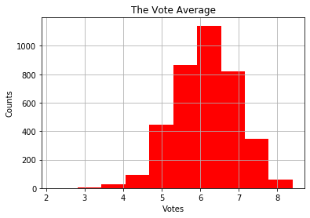

```python
df.vote_average.hist(color='red');
plt.title('The Vote Average');
plt.xlabel('Votes');
plt.ylabel('Counts');
```

### as you can see between 6 and 7 is the biggest count of movies!

# The Release Years of the Movies!

# At wich year there is the highest counts of movies ?

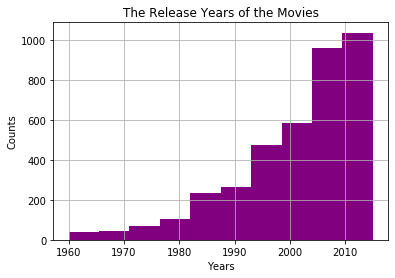

```python
df.release_year.hist(color='purple');
plt.title('The Release Years of the Movies');
plt.xlabel('Years');
plt.ylabel('Counts');
```

### as you can see after the 90's, the Movie count is getting bigger and bigger!

# Compare between the budget and Release Year

# is the Release Year affect on the Budget of the movies ??

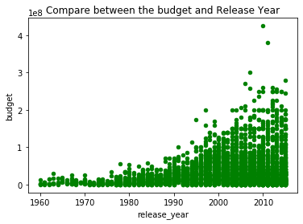

```python
df.plot(x="release_year", y="budget", kind="scatter", color='green');
plt.title('Compare between the budget and Release Year');
```

## as you can see before in the 1960's the budget was very low but now the budget is getting very high !

# In Conclusion:

## After i did the analysis of this dataset there are somethings that got in my way,

## and i found it difficult to deal with it Like the Null values, should i just drop them ?

## or get the (mean) and fill them with it, something Like that...